# Case Study: Cyclistic Bike Share

Thuan Khang Dinh

2025-01-03

# README:

# Overview:

In this study, we will get better understanding about the difference of annual members and casual members using bikes. Our objective is to delve into the Cyclistic historical bike trip data, analyzing patterns, preferences, and behaviors of these two distinct groups.

The business goal is to design the strategies to maximizing the number of annual memberships, backed up with compelling data insights and data visualizations, which have been identified that more profitable for Cyclistic.

# STEP 1: ASK

## 1.1 Company backgroud:

Cyclistic is a bike-share company in Chicago, offering a fleet of bicycles and locked into a network of stations across the city. The bikes can be unlocked from one station and returned to any other station in the system anytime. Cyclistic operates in a subscription-based model, with optios of casual members and annual members.

## 1.2 Key stakeholders:

**1. Lily Moreno:** The director of marketing who is responsible for the development of campaigns and initiative to promote the bike-share program.

**2. Cyclistic marketing analytics team:** The team is responsible for collecting, analyzing, and reporting data that helps guide Cyclistic marketing strategy.

**3. Cyclistic executive team:** The team will decide whether to approve the recommended marketing program.

## 1.3 Problem Statement:

Understanding the difference between casual members and annual riders of Cyclistic bikes to design a new marketing strategy of converting casual riders to annual users.

## 1.4 Business Task:

Analyze the Cyclistic’s history bike trip data to understand the differences and use those insights to design a marketing strategy to convert casual to annual riders.

## 1.5 Deliverable:

1. A clear statement of the business task.
2. A description of all data sources used.
3. Documentation of any cleaning or manipulation of data.
4. A summary of the analysis.
5. Supporting visualization and key findings.
6. The top three recommendation based on the analysis.

## 1.6 Data Context:

Our data, derived from Cyclistic’s historical trip records, includes a complete year of ride data, providing insights into the usage patterns of both casual and annual members. The crucial variables in our dataset include each trip’s start and end times, start and end station details, rideable type, and whether the rider is a casual or annual member.

# STEP 2: PREPARE

## 2.1 Information on Data Source:

1. In this case study, I am using the Public Bike Trip Data from the [Divvy Bikes website](https://divvybikes.com/system-data): [Datasets from January 2023 to December 2023](https://divvy-tripdata.s3.amazonaws.com/index.html).
2. The data for this case study is provided by [Motivate International Inc](https://www.divvybikes.com/data-license-agreement), has been made publicly available for download.
3. The data represent historical trip data of Cyclistic bikes, in format of CSV, with each row is a trip, and columns indicate features such as `trip type`, `start and end time`, `start and end station`, and `user type`.

## 2.2 Limitations of Data Set:

1. Data-privacy issues prohibit from using riders’ personally identifiable information, so we cannot do biological related analysis.
2. The data only includes people who have chosen to use the Cyclistic service, and might not represent the entire population of bike riders in Chicago.

## 2.3 Is Data ROCCC:

ROCCC stands for **R**eliable, **O**riginal, **C**omprehensive, **C**urrent, and **C**ited.

1. Reliable – High – The data is collected and provided by the company that operates the bicycle sharing service in Chicago, under the authority of the City.
2. Original – High – The data originates directly from Bikeshare’s operations of the Divvy service. It is not derived from secondary sources, so it is authentic and directly related to the service’s operation.
3. Comprehensive – Moderate – The license grants access to certain Divvy system data, which implies that the data may not be fully comprehensive.
4. Current – High – It does not provide details on how often the data is updated in license, but if you take a look at the data provided, it does update monthly.
5. Cited – Low – No explicit citation requirement.

## 2.4 Import Data:

- Importing trip data Jan 2023: TRUE
- Importing trip data Feb 2023: TRUE
- Importing trip data Mar 2023: TRUE
- Importing trip data Apr 2023: TRUE
- Importing trip data May 2023: TRUE
- Importing trip data Jun 2023: TRUE
- Importing trip data Jul 2023: TRUE
- Importing trip data Aug 2023: TRUE
- Importing trip data Sep 2023: TRUE
- Importing trip data Oct 2023: TRUE
- Importing trip data Nov 2023: TRUE
- Importing trip data Dec 2023: TRUE

## 2.5 Understand the data

As all the datasets have the same columns, we will inspect only one of those, we choose `tripdata_2023_01`.

```r
str(tripdata_2023_01)
```

```
## 'data.frame':    190301 obs. of  13 variables:
##  $ ride_id           : chr  "F96D5A74A3E41399" "13CB7EB698CEDB88" "BD88A2E670661CE5" "C90792D034FED968" ...
##  $ rideable_type     : chr  "electric_bike" "classic_bike" "electric_bike" "classic_bike" ...
##  $ started_at        : chr  "2023-01-21 20:05:42" "2023-01-10 15:37:36" "2023-01-02 07:51:57" "2023-01-22 10:52:58" ...
##  $ ended_at          : chr  "2023-01-21 20:16:33" "2023-01-10 15:46:05" "2023-01-02 08:05:11" "2023-01-22 11:01:44" ...
##  $ start_station_name: chr  "Lincoln Ave & Fullerton Ave" "Kimbark Ave & 53rd St" "Western Ave & Lunt Ave" "Kimbark Ave & 53rd St" ...
##  $ start_station_id  : chr  "TA1309000058" "TA1309000037" "RP-005" "TA1309000037" ...
##  $ end_station_name  : chr  "Hampden Ct & Diversey Ave" "Greenwood Ave & 47th St" "Valli Produce - Evanston Plaza" "Greenwood Ave & 47th St" ...
##  $ end_station_id    : chr  "202480.0" "TA1308000002" "599" "TA1308000002" ...
##  $ start_lat         : num  41.9 41.8 42 41.8 41.8 ...
##  $ start_lng         : num  -87.6 -87.6 -87.7 -87.6 -87.6 ...
##  $ end_lat           : num  41.9 41.8 42 41.8 41.8 ...
##  $ end_lng           : num  -87.6 -87.6 -87.7 -87.6 -87.6 ...
##  $ member_casual     : chr  "member" "member" "casual" "member" ...
```

```r
head(tripdata_2023_01)
```

```
##            ride_id rideable_type          started_at            ended_at
## 1 F96D5A74A3E41399 electric_bike 2023-01-21 20:05:42 2023-01-21 20:16:33
## 2 13CB7EB698CEDB88  classic_bike 2023-01-10 15:37:36 2023-01-10 15:46:05
## 3 BD88A2E670661CE5 electric_bike 2023-01-02 07:51:57 2023-01-02 08:05:11
## 4 C90792D034FED968  classic_bike 2023-01-22 10:52:58 2023-01-22 11:01:44
## 5 3397017529188E8A  classic_bike 2023-01-12 13:58:01 2023-01-12 14:13:20
## 6 58E68156DAE3E311 electric_bike 2023-01-31 07:18:03 2023-01-31 07:21:16
##              start_station_name start_station_id               end_station_name
## 1   Lincoln Ave & Fullerton Ave     TA1309000058      Hampden Ct & Diversey Ave
## 2         Kimbark Ave & 53rd St     TA1309000037        Greenwood Ave & 47th St
## 3        Western Ave & Lunt Ave           RP-005 Valli Produce - Evanston Plaza
## 4         Kimbark Ave & 53rd St     TA1309000037        Greenwood Ave & 47th St
## 5         Kimbark Ave & 53rd St     TA1309000037        Greenwood Ave & 47th St
## 6 Lakeview Ave & Fullerton Pkwy     TA1309000019      Hampden Ct & Diversey Ave
##   end_station_id start_lat start_lng  end_lat   end_lng member_casual
## 1       202480.0  41.92407 -87.64628 41.93000 -87.64000        member
## 2   TA1308000002  41.79957 -87.59475 41.80983 -87.59938        member
## 3            599  42.00857 -87.69048 42.03974 -87.69941        casual
## 4   TA1308000002  41.79957 -87.59475 41.80983 -87.59938        member
## 5   TA1308000002  41.79957 -87.59475 41.80983 -87.59938        member
## 6       202480.0  41.92607 -87.63886 41.93000 -87.64000        member
```

The dataset is organized as we said, so we are safe to come to next step.

# STEP 3: PROCESS

In this step, I will do several things:

- Merged all dataframes into one dataframe: using `UNION ALL`
- Add column `ride_length`: using `julianday(ended_at) - julianday(started_at)` and `AS ride_length`
- Add column `day_of_week`: using `strftime('%w', started_at) AS day_of_week`
- Get rid of any observations which have NA value: using `WHERE ... IS NOT NULL`
- Get rid of case where `started_at` is after `ended_at`: using `datetime(started_at) <= datetime(ended_at)`
- Change name `started_at` to `start_at` and `ended_at` to `end_at`.
- Get rid of `lat` and `lng`.

The `query`:

```
SELECT ride_id, rideable_type,
      started_at AS start_at,
      ended_at AS end_at,
      member_casual,
      start_station_name, start_station_id,
      end_station_name, end_station_id,
      CAST((julianday(ended_at) - julianday(started_at)) * 86400 AS INTEGER) AS ride_length,
      CASE
        WHEN strftime('%w', started_at) = '0' THEN 'Sunday'
        WHEN strftime('%w', started_at) = '1' THEN 'Monday'
        WHEN strftime('%w', started_at) = '2' THEN 'Tuesday'
        WHEN strftime('%w', started_at) = '3' THEN 'Wednesday'
        WHEN strftime('%w', started_at) = '4' THEN 'Thursday'
        WHEN strftime('%w', started_at) = '5' THEN 'Friday'
        WHEN strftime('%w', started_at) = '6' THEN 'Saturday'
      END AS day_of_week,

      CASE
         WHEN CAST(strftime('%H', started_at) AS INTEGER) BETWEEN 0 AND 5 THEN 'Early Morning'
         WHEN CAST(strftime('%H', started_at) AS INTEGER) BETWEEN 6 AND 8 THEN 'Morning Commute'
         WHEN CAST(strftime('%H', started_at) AS INTEGER) BETWEEN 9 AND 14 THEN 'Midday'
         WHEN CAST(strftime('%H', started_at) AS INTEGER) BETWEEN 15 AND 18 THEN 'Evening Commute'
         WHEN CAST(strftime('%H', started_at) AS INTEGER) BETWEEN 19 AND 23 THEN 'Night'
      END AS time_interval,
      strftime('%m', started_at) AS month

FROM  tripdata_2023_01

WHERE ride_id IS NOT NULL AND
   rideable_type IS NOT NULL AND
   started_at IS NOT NULL AND
   ended_at IS NOT NULL AND
   start_station_name IS NOT NULL AND
   start_station_id IS NOT NULL AND
   end_station_name IS NOT NULL AND
   end_station_id IS NOT NULL AND
   member_casual IS NOT NULL AND
   CAST((julianday(ended_at) - julianday(started_at)) * 86400 AS INTEGER) > 0

UNION ALL

...
```

```
## 'data.frame':    5710248 obs. of  13 variables:
##  $ ride_id           : chr  "F96D5A74A3E41399" "13CB7EB698CEDB88" "BD88A2E670661CE5" "C90792D034FED968" ...
##  $ rideable_type     : chr  "electric_bike" "classic_bike" "electric_bike" "classic_bike" ...
##  $ start_at          : chr  "2023-01-21 20:05:42" "2023-01-10 15:37:36" "2023-01-02 07:51:57" "2023-01-22 10:52:58" ...
##  $ end_at            : chr  "2023-01-21 20:16:33" "2023-01-10 15:46:05" "2023-01-02 08:05:11" "2023-01-22 11:01:44" ...
##  $ member_casual     : chr  "member" "member" "casual" "member" ...
##  $ start_station_name: chr  "Lincoln Ave & Fullerton Ave" "Kimbark Ave & 53rd St" "Western Ave & Lunt Ave" "Kimbark Ave & 53rd St" ...
##  $ start_station_id  : chr  "TA1309000058" "TA1309000037" "RP-005" "TA1309000037" ...
##  $ end_station_name  : chr  "Hampden Ct & Diversey Ave" "Greenwood Ave & 47th St" "Valli Produce - Evanston Plaza" "Greenwood Ave & 47th St" ...
##  $ end_station_id    : chr  "202480.0" "TA1308000002" "599" "TA1308000002" ...
##  $ ride_length       : int  651 509 793 526 919 192 840 560 747 753 ...
##  $ day_of_week       : chr  "Saturday" "Tuesday" "Monday" "Sunday" ...
##  $ time_interval     : chr  "Night" "Evening Commute" "Morning Commute" "Midday" ...
##  $ month             : chr  "01" "01" "01" "01" ...
```

# STEP 4: ANALYZE

## Overall:

Here is a summary table:

```r
query = "
SELECT member_casual,
      COUNT(*) AS number_of_rides,
      SUM(ride_length) AS total_ride_duration,
      AVG(ride_length) AS average_ride_duration,
      MAX(ride_length) AS max_ride_duration
FROM merged_data
GROUP BY member_casual;
"

ride_summary = sqldf(query)
ride_summary
```

```
##   member_casual number_of_rides total_ride_duration average_ride_duration
## 1        casual         2052231          2544034947             1239.6436
## 2        member         3658017          2649192185              724.2154
##   max_ride_duration
## 1            728178
## 2             89996
```

**Insight:**

- Members take significantly more rides than casual riders (1.7824587 more), which indicate that members might use service as a regular mode of transportation, while casual riders use for occasional or recreational purposes.
- Casual riders account for a nearly equivalent ride duration compared to members.
- Casual riders spend almost twice as long on average per ride compared to members, which indicate that casual riders are likely using longer and more relaxed rides for leisure…, while members use bike for more practical purposes, so trips are shorter.
- Casual riders have significantly longer maximum trip durations, may be for special activities, while members rarely take long trips, likely due to structured usage patterns.

## By day of week:

### Table

#### Table Number of Rides:

```r
query = "
SELECT member_casual AS user_type,
       SUM(CASE WHEN day_of_week = 'Sunday' THEN 1 ELSE 0 END) AS Sunday,
       SUM(CASE WHEN day_of_week = 'Monday' THEN 1 ELSE 0 END) AS Monday,
       SUM(CASE WHEN day_of_week = 'Tuesday' THEN 1 ELSE 0 END) AS Tuesday,
       SUM(CASE WHEN day_of_week = 'Wednesday' THEN 1 ELSE 0 END) AS Wednesday,
       SUM(CASE WHEN day_of_week = 'Thursday' THEN 1 ELSE 0 END) AS Thursday,
       SUM(CASE WHEN day_of_week = 'Friday' THEN 1 ELSE 0 END) AS Friday,
       SUM(CASE WHEN day_of_week = 'Saturday' THEN 1 ELSE 0 END) AS Saturday
FROM merged_data
GROUP BY member_casual;
"
rides_by_day_of_week = sqldf(query)
rides_by_day_of_week
```

```
##   user_type Sunday Monday Tuesday Wednesday Thursday Friday Saturday
## 1    casual 334335 234073  245484    248432   269779 310918   409210
## 2    member 408540 494233  576324    586060   589169 531217   472474
```

#### Table Total Ride Duration:

```r
query = "
SELECT member_casual AS user_type,
       SUM(CASE WHEN day_of_week = 'Sunday' THEN ride_length ELSE 0 END) AS Sunday,
       SUM(CASE WHEN day_of_week = 'Monday' THEN ride_length ELSE 0 END) AS Monday,
       SUM(CASE WHEN day_of_week = 'Tuesday' THEN ride_length ELSE 0 END) AS Tuesday,
       SUM(CASE WHEN day_of_week = 'Wednesday' THEN ride_length ELSE 0 END) AS Wednesday,
       SUM(CASE WHEN day_of_week = 'Thursday' THEN ride_length ELSE 0 END) AS Thursday,
       SUM(CASE WHEN day_of_week = 'Friday' THEN ride_length ELSE 0 END) AS Friday,
       SUM(CASE WHEN day_of_week = 'Saturday' THEN ride_length ELSE 0 END) AS Saturday
FROM merged_data
GROUP BY member_casual;
"
total_ride_duration_by_day_of_week = sqldf(query)
total_ride_duration_by_day_of_week
```

```
##   user_type    Sunday    Monday   Tuesday Wednesday  Thursday    Friday
## 1    casual 482222741 285501489 272290787 263753153 291919276 373913554
## 2    member 329956378 340408247 400626527 405416184 409600390 382713598
##    Saturday
## 1 574433947
## 2 380470861
```

It somewhat hard to see, so I will change the unit into `hour`:

```r
total_ride_duration_by_day_of_week[-1] = total_ride_duration_by_day_of_week[-1] / 3600
total_ride_duration_by_day_of_week
```

```
##   user_type    Sunday   Monday   Tuesday Wednesday  Thursday   Friday Saturday
## 1    casual 133950.76 79305.97  75636.33  73264.76  81088.69 103864.9 159565.0
## 2    member  91654.55 94557.85 111285.15 112615.61 113777.89 106309.3 105686.4
```

#### Table Average Ride Duration:

```r
query = "
SELECT member_casual AS user_type,
       AVG(CASE WHEN day_of_week = 'Sunday' THEN ride_length END) AS Sunday,
       AVG(CASE WHEN day_of_week = 'Monday' THEN ride_length END) AS Monday,
       AVG(CASE WHEN day_of_week = 'Tuesday' THEN ride_length END) AS Tuesday,
       AVG(CASE WHEN day_of_week = 'Wednesday' THEN ride_length END) AS Wednesday,
       AVG(CASE WHEN day_of_week = 'Thursday' THEN ride_length END) AS Thursday,
       AVG(CASE WHEN day_of_week = 'Friday' THEN ride_length END) AS Friday,
       AVG(CASE WHEN day_of_week = 'Saturday' THEN ride_length END) AS Saturday
FROM merged_data
GROUP BY member_casual;
"
avg_ride_duration_by_day_of_week = sqldf(query)
avg_ride_duration_by_day_of_week
```

```
##   user_type    Sunday    Monday   Tuesday Wednesday  Thursday    Friday
## 1    casual 1442.3340 1219.7113 1109.1997 1061.6714 1082.0682 1202.6115
## 2    member  807.6477  688.7607  695.1411  691.7657  695.2171  720.4468
##    Saturday
## 1 1403.7632
## 2  805.2736
```

### Visualize

#### Prepare dataframe for visualization:

```r
query = "
SELECT member_casual AS user_type, day_of_week, COUNT(*) AS num_rides, SUM(ride_length) AS total_duration, AVG(ride_length) AS average_duration
FROM merged_data
GROUP BY user_type, day_of_week
ORDER BY
    CASE
        WHEN day_of_week = 'Sunday' THEN 1
        WHEN day_of_week = 'Monday' THEN 2
        WHEN day_of_week = 'Tuesday' THEN 3
        WHEN day_of_week = 'Wednesday' THEN 4
        WHEN day_of_week = 'Thursday' THEN 5
        WHEN day_of_week = 'Friday' THEN 6
        WHEN day_of_week = 'Saturday' THEN 7
    END;
"
df_by_day_of_week = sqldf(query)
#For order x-axis
df_by_day_of_week$day_of_week = factor(df_by_day_of_week$day_of_week, levels=unique(df_by_day_of_week$day_of_week))
```

#### Multiple Bar Plot for Number of Rides:

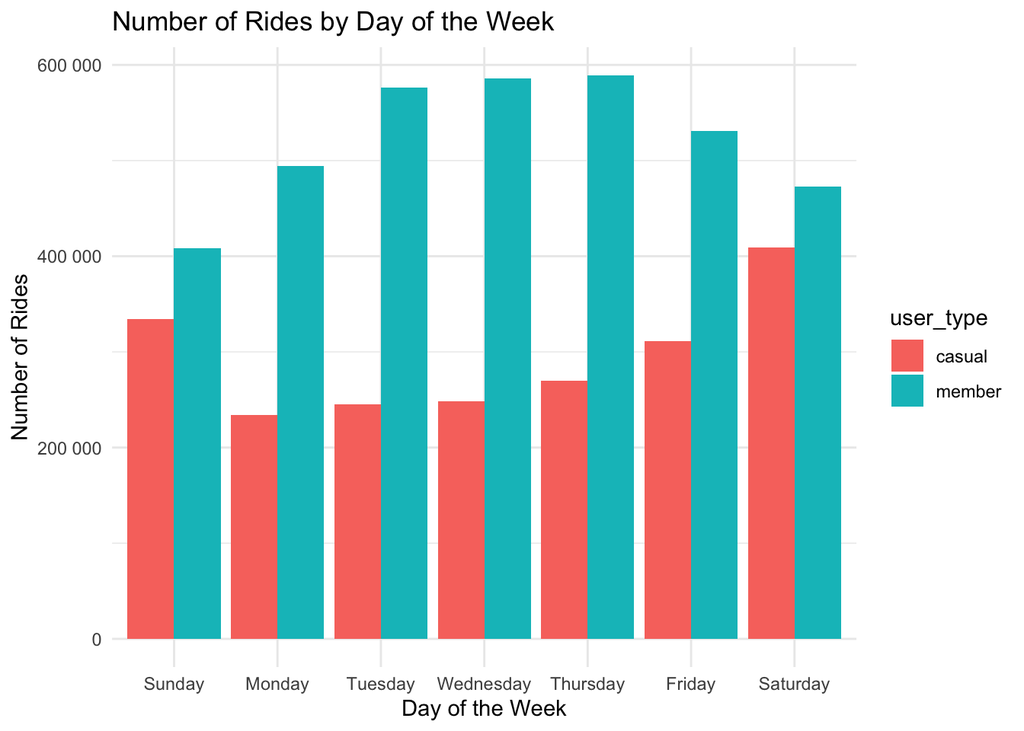

```r
ggplot(df_by_day_of_week, aes(x = day_of_week, y = num_rides, fill = user_type)) +
  geom_bar(stat = "identity", position = "dodge") +
  labs(title = "Number of Rides by Day of the Week",
       x = "Day of the Week",
       y = "Number of Rides") +
  theme_minimal() +
  scale_y_continuous(labels = scales::label_number())
```

#### Multiple Bar Plot for Total Ride Duration:

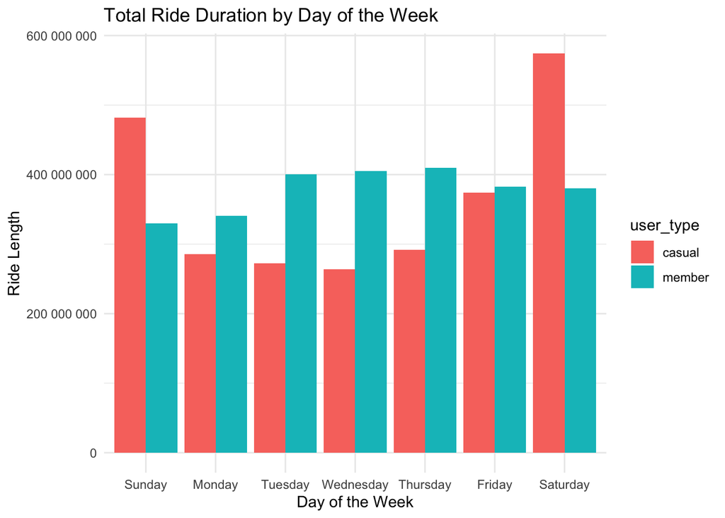

```r
ggplot(df_by_day_of_week, aes(x = day_of_week, y = total_duration, fill = user_type)) +
  geom_bar(stat = "identity", position = "dodge") +
  labs(title = "Total Ride Duration by Day of the Week",
       x = "Day of the Week",
       y = "Ride Length") +
  theme_minimal() +
  scale_y_continuous(labels = scales::label_number())
```

#### Multiple Bar Plot for Average Ride Duration:

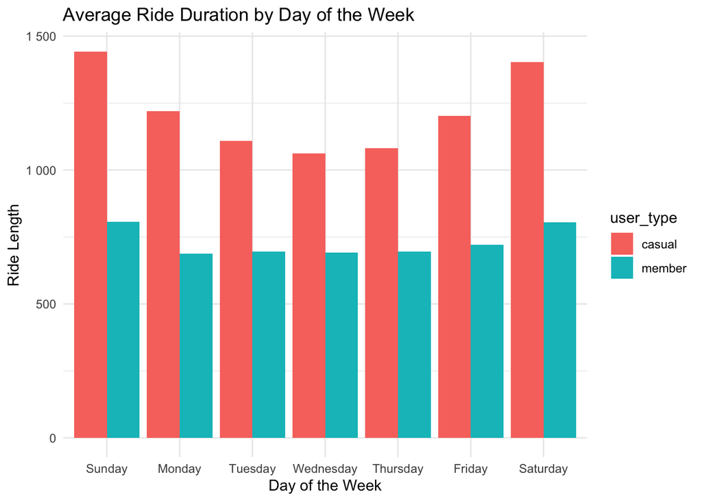

```r
ggplot(df_by_day_of_week, aes(x = day_of_week, y = average_duration, fill = user_type)) +
  geom_bar(stat = "identity", position = "dodge") +
  labs(title = "Average Ride Duration by Day of the Week",
       x = "Day of the Week",
       y = "Ride Length") +
  theme_minimal() +
  scale_y_continuous(labels = scales::label_number())
```

**Insight:**

- Casual users primarily use the service on Friday, Saturday and Sunday, indicating more leisure or occasional usage.
- Members use the service more consistently throughout the week, with higher usage on weekdays, particularly on Thursday, suggesting more regular or commuter-based usage.

## By time interval:

Let define something first:

- I will use start time only, because it provides a string indication of when users decide to take a trip.
- I will split the day into 5 intervals that align with potential user behavior:
  - **Early Morning (12:00 AM - 6:00 AM):** Night-shift workers, late-night leisure riders, or early commutes.
  - **Morning Commute (6:00 AM - 9:00 AM):** Typical morning rush hours.
  - **Midday (9:00 AM - 3:00 PM):** More relaxed period, include leisure rides, running errands, or flexible work schedules.
  - **Evening Commute (3:00 PM - 7:00 PM):** Peak usage time as people return home form work or school.
  - **Night (7:00 PM - 12:00 AM):** Leisure, social outings, or exercise.

### Table

#### Table Number of Rides:

```r
query = "
SELECT member_casual AS user_type,
       SUM(CASE WHEN time_interval = 'Early Morning' THEN 1 ELSE 0 END) AS EarlyMorning,
       SUM(CASE WHEN time_interval = 'Morning Commute' THEN 1 ELSE 0 END) AS MorningCommute,
       SUM(CASE WHEN time_interval = 'Midday' THEN 1 ELSE 0 END) AS Midday,
       SUM(CASE WHEN time_interval = 'Evening Commute' THEN 1 ELSE 0 END) AS EveningCommute,
       SUM(CASE WHEN time_interval = 'Night' THEN 1 ELSE 0 END) AS Night
FROM merged_data
GROUP BY member_casual;
"
rides_by_time_interval = sqldf(query)
rides_by_time_interval
```

```
##   user_type EarlyMorning MorningCommute  Midday EveningCommute  Night
## 1    casual       100014         153516  675093         710920 412688
## 2    member       119719         543824 1089907        1273184 631383
```

#### Table Total Ride Duration:

```r
query = "
SELECT member_casual AS user_type,
       SUM(CASE WHEN time_interval = 'Early Morning' THEN ride_length ELSE 0 END) AS EarlyMorning,
       SUM(CASE WHEN time_interval = 'Morning Commute' THEN ride_length ELSE 0 END) AS MorningCommute,
       SUM(CASE WHEN time_interval = 'Midday' THEN ride_length ELSE 0 END) AS Midday,
       SUM(CASE WHEN time_interval = 'Evening Commute' THEN ride_length ELSE 0 END) AS EveningCommute,
       SUM(CASE WHEN time_interval = 'Night' THEN ride_length ELSE 0 END) AS Night
FROM merged_data
GROUP BY member_casual;
"
total_ride_duration_by_time_interval = sqldf(query)
total_ride_duration_by_time_interval
```

```
##   user_type EarlyMorning MorningCommute    Midday EveningCommute     Night
## 1    casual    104758316      136213008 964138986      876713613 462211024
## 2    member     80581034      355520945 788148865      966982484 457958857
```

#### Table Average Ride Duration:

```r
query = "
SELECT member_casual AS user_type,
       AVG(CASE WHEN time_interval = 'Early Morning' THEN ride_length ELSE 0 END) AS EarlyMorning,
       AVG(CASE WHEN time_interval = 'Morning Commute' THEN ride_length ELSE 0 END) AS MorningCommute,
       AVG(CASE WHEN time_interval = 'Midday' THEN ride_length ELSE 0 END) AS Midday,
       AVG(CASE WHEN time_interval = 'Evening Commute' THEN ride_length ELSE 0 END) AS EveningCommute,
       AVG(CASE WHEN time_interval = 'Night' THEN ride_length ELSE 0 END) AS Night
FROM merged_data
GROUP BY member_casual;
"
avg_ride_duration_by_time_interval = sqldf(query)
avg_ride_duration_by_time_interval
```

[output not shown]

### Visualize

#### Prepare dataframe for visualization:

```r
query = "
SELECT member_casual AS user_type, time_interval, COUNT(*) AS num_rides, SUM(ride_length) AS total_duration, AVG(ride_length) AS average_duration
FROM merged_data
GROUP BY user_type, time_interval
ORDER BY
    CASE
        WHEN time_interval = 'Early Morning' THEN 1
        WHEN time_interval = 'Morning Commute' THEN 2
        WHEN time_interval = 'Midday' THEN 3
        WHEN time_interval = 'Evening Commute' THEN 4
        WHEN time_interval = 'Night' THEN 5
    END;
"
df_by_time_interval = sqldf(query)
#For order x-axis
df_by_time_interval$time_interval = factor(df_by_time_interval$time_interval, levels=unique(df_by_time_interval$time_interval))
```

#### Multiple Bar Plot for Number of Rides:

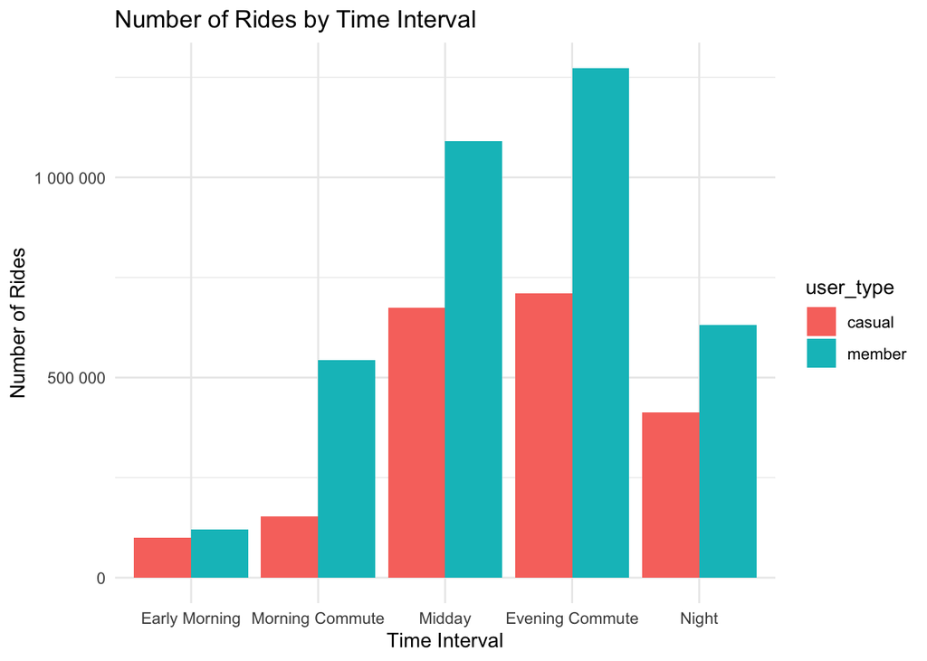

```r
ggplot(df_by_time_interval, aes(x = time_interval, y = num_rides, fill = user_type)) +
  geom_bar(stat = "identity", position = "dodge") +
  labs(title = "Number of Rides by Time Interval",
       x = "Time Interval",
       y = "Number of Rides") +
  theme_minimal() +
  scale_y_continuous(labels = scales::label_number())
```

#### Multiple Bar Plot for Total Ride Duration:

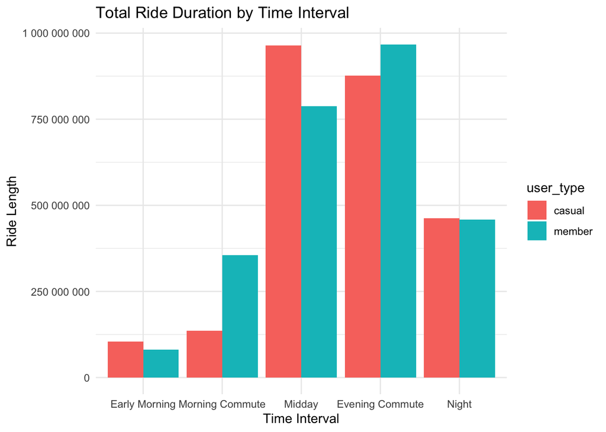

```r
ggplot(df_by_time_interval, aes(x = time_interval, y = total_duration, fill = user_type)) +
  geom_bar(stat = "identity", position = "dodge") +
  labs(title = "Total Ride Duration by Time Interval",
       x = "Time Interval",
       y = "Ride Length") +
  theme_minimal() +
  scale_y_continuous(labels = scales::label_number())
```

#### Multiple Bar Plot for Average Ride Duration:

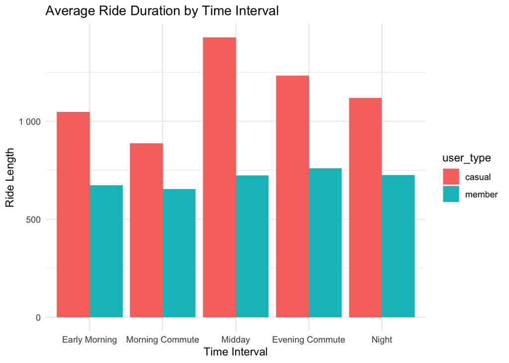

```r
ggplot(df_by_time_interval, aes(x = time_interval, y = average_duration, fill = user_type)) +
  geom_bar(stat = "identity", position = "dodge") +
  labs(title = "Average Ride Duration by Time Interval",
       x = "Time Interval",
       y = "Ride Length") +
  theme_minimal() +
  scale_y_continuous(labels = scales::label_number())
```

## By month:

### Table

#### Table Number of Rides:

```r
query = "
SELECT member_casual AS user_type,
       SUM(CASE WHEN month = '01' THEN 1 ELSE 0 END) AS Jan,
       SUM(CASE WHEN month = '02' THEN 1 ELSE 0 END) AS Feb,
       SUM(CASE WHEN month = '03' THEN 1 ELSE 0 END) AS Mar,
       SUM(CASE WHEN month = '04' THEN 1 ELSE 0 END) AS Apr,
       SUM(CASE WHEN month = '05' THEN 1 ELSE 0 END) AS May,
       SUM(CASE WHEN month = '06' THEN 1 ELSE 0 END) AS Jun,
       SUM(CASE WHEN month = '07' THEN 1 ELSE 0 END) AS Jul,
       SUM(CASE WHEN month = '08' THEN 1 ELSE 0 END) AS Aug,
       SUM(CASE WHEN month = '09' THEN 1 ELSE 0 END) AS Sep,
       SUM(CASE WHEN month = '10' THEN 1 ELSE 0 END) AS Oct,
       SUM(CASE WHEN month = '11' THEN 1 ELSE 0 END) AS Nov,
       SUM(CASE WHEN month = '12' THEN 1 ELSE 0 END) AS Dec
FROM merged_data
GROUP BY member_casual;
"
rides_by_month = sqldf(query)
rides_by_month
```

```
##   user_type    Jan    Feb    Mar    Apr    May    Jun    Jul    Aug    Sep
## 1    casual  39899  42920  62039 146867 233531 300362 329987 309834 260761
## 2    member 150244 147383 196403 279214 370438 418164 435882 460110 404351
##      Oct    Nov    Dec
## 1 176495  98055  51481
## 2 359713 263874 172241
```

#### Table Total Ride Duration:

```r
query = "
SELECT member_casual AS user_type,
       SUM(CASE WHEN month = '01' THEN ride_length ELSE 0 END) AS Jan,
       SUM(CASE WHEN month = '02' THEN ride_length ELSE 0 END) AS Feb,
       SUM(CASE WHEN month = '03' THEN ride_length ELSE 0 END) AS Mar,
       SUM(CASE WHEN month = '04' THEN ride_length ELSE 0 END) AS Apr,
       SUM(CASE WHEN month = '05' THEN ride_length ELSE 0 END) AS May,
       SUM(CASE WHEN month = '06' THEN ride_length ELSE 0 END) AS Jun,
       SUM(CASE WHEN month = '07' THEN ride_length ELSE 0 END) AS Jul,
       SUM(CASE WHEN month = '08' THEN ride_length ELSE 0 END) AS Aug,
       SUM(CASE WHEN month = '09' THEN ride_length ELSE 0 END) AS Sep,
       SUM(CASE WHEN month = '10' THEN ride_length ELSE 0 END) AS Oct,
       SUM(CASE WHEN month = '11' THEN ride_length ELSE 0 END) AS Nov,
       SUM(CASE WHEN month = '12' THEN ride_length ELSE 0 END) AS Dec
FROM merged_data
GROUP BY member_casual;
"
total_ride_duration_by_month = sqldf(query)
total_ride_duration_by_month
```

```
##   user_type      Jan      Feb       Mar       Apr       May       Jun       Jul
## 1    casual 32519867 41014601  56527220 179681516 308333145 391260097 449947793
## 2    member 91203109 92722226 120204850 191868192 279034117 322415543 345379777
##         Aug       Sep       Oct       Nov       Dec
## 1 408445438 332398824 202033962  95207579  46664905
## 2 364118630 306411059 249881461 174029500 111923721
```

#### Table Average Ride Duration:

```r
query = "
SELECT member_casual AS user_type,
       AVG(CASE WHEN month = '01' THEN ride_length END) AS Jan,
       AVG(CASE WHEN month = '02' THEN ride_length END) AS Feb,
       AVG(CASE WHEN month = '03' THEN ride_length END) AS Mar,
       AVG(CASE WHEN month = '04' THEN ride_length END) AS Apr,
       AVG(CASE WHEN month = '05' THEN ride_length END) AS May,
       AVG(CASE WHEN month = '06' THEN ride_length END) AS Jun,
       AVG(CASE WHEN month = '07' THEN ride_length END) AS Jul,
       AVG(CASE WHEN month = '08' THEN ride_length END) AS Aug,
       AVG(CASE WHEN month = '09' THEN ride_length END) AS Sep,
       AVG(CASE WHEN month = '10' THEN ride_length END) AS Oct,
       AVG(CASE WHEN month = '11' THEN ride_length END) AS Nov,
       AVG(CASE WHEN month = '12' THEN ride_length END) AS Dec
FROM merged_data
GROUP BY member_casual;
"
avg_ride_duration_by_month = sqldf(query)
avg_ride_duration_by_month
```

```
##   user_type      Jan      Feb      Mar       Apr       May       Jun       Jul
## 1    casual 815.0547 955.6058 911.1562 1223.4302 1320.3093 1302.6285 1363.5319
## 2    member 607.0333 629.1243 612.0316  687.1725  753.2546  771.0265  792.3699
##        Aug       Sep      Oct      Nov      Dec
## 1 1318.272 1274.7260 1144.701 970.9610 906.4491
## 2  791.373  757.7848  694.669 659.5174 649.8088
```

### Visualize

#### Prepare dataframe for visualization:

```r
query = "
SELECT member_casual AS user_type, month, COUNT(*) AS num_rides, SUM(ride_length) AS total_duration, AVG(ride_length) AS average_duration
FROM merged_data
GROUP BY user_type, month
ORDER BY
    CASE
        WHEN month = '01' THEN 1
        WHEN month = '02' THEN 2
        WHEN month = '03' THEN 3
        WHEN month = '04' THEN 4
        WHEN month = '05' THEN 5
        WHEN month = '06' THEN 6
        WHEN month = '07' THEN 7
        WHEN month = '08' THEN 8
        WHEN month = '09' THEN 9
        WHEN month = '10' THEN 10
        WHEN month = '11' THEN 11
        WHEN month = '12' THEN 12
    END;
"
df_by_month = sqldf(query)
#For order x-axis
df_by_month$month = factor(df_by_month$month, levels=unique(df_by_month$month))
```

#### Multiple Bar Plot for Number of Rides:

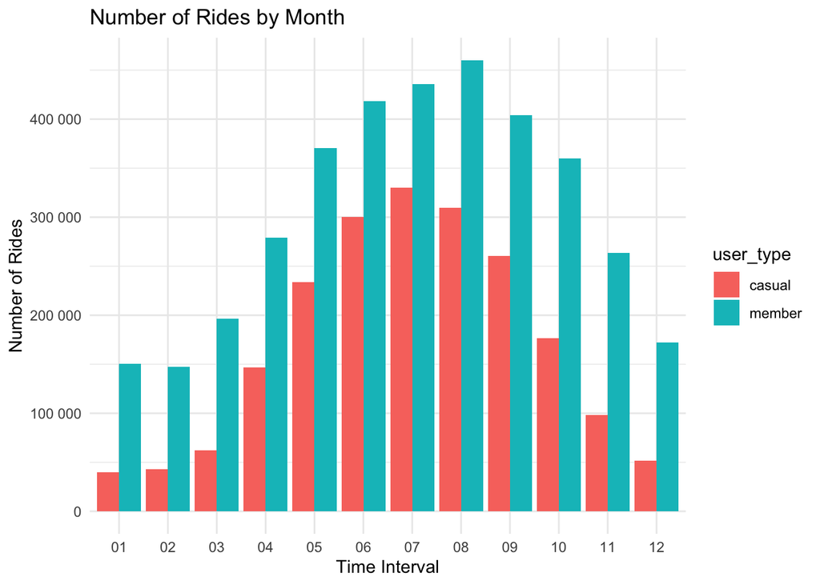

```r
ggplot(df_by_month, aes(x = month, y = num_rides, fill = user_type)) +
  geom_bar(stat = "identity", position = "dodge") +
  labs(title = "Number of Rides by Month",
       x = "Time Interval",
       y = "Number of Rides") +
  theme_minimal() +
  scale_y_continuous(labels = scales::label_number())
```

#### Multiple Bar Plot for Total Ride Duration:

[figure not shown]

```r
ggplot(df_by_month, aes(x = month, y = total_duration, fill = user_type)) +
  geom_bar(stat = "identity", position = "dodge") +
  labs(title = "Number of Rides by Month",
       x = "Time Interval",
       y = "Number of Rides") +
  theme_minimal() +
  scale_y_continuous(labels = scales::label_number())
```

#### Multiple Bar Plot for Average Ride Duration:

[figure not shown]

```r
ggplot(df_by_month, aes(x = month, y = average_duration, fill = user_type)) +
  geom_bar(stat = "identity", position = "dodge") +
  labs(title = "Number of Rides by Month",
       x = "Time Interval",
       y = "Number of Rides") +
  theme_minimal() +
  scale_y_continuous(labels = scales::label_number())
```

**Insight:**

- Casual Users rides peak during the summer months, strongly indicating that their primary use is for leisure or recreational purposes. This behavior is heavily influenced by warm weather, aligning with seasonal outdoor activities.
- Member’s rides show a more consistent pattern throughout the year, with less dramatic seasonal variation compared to casual users. This suggests that members likely use bikes not just for recreation, but also for commuting or other routine activities, making their usage more practical and need-based.